```python
!pip install wget
```

```python
from functools import partial
import glob
import os
import shutil
import requests

from sklearn.model_selection import train_test_split
import zipfile
import wget
import tarfile
import xml.etree.ElementTree as ET
import pandas as pd
import tensorflow as tf

print(tf.__version__)
```

```
2.8.0
```

# Step 1: Prerequisites

### Gather and label image.

- [Label Studio](https://labelstud.io/) is used to prepare dataset for this notebook.
- Annotated images were exported as Pascal VOC dataset.
- This dataset is then compressed as zip file.

# Step 2: Set up the directory structure on Google Drive

### 1. Setup folders in google drive

```
custom_detector               # set as root directory
└─── workspace
    ├─── proj_facemask        # current project workspace
    │    ├─── annotations
    │    ├─── exported-models
    │    ├─── images
    │    │    ├─── test
    │    │    └─── train
    │    ├─── models
    │    └─── pre-trained-models
    │
    ├─── project n            # workspace for project n
    ...
```

References:  
[1] [Creating multiple subdirectories](https://www.geeksforgeeks.org/make-multiple-directories-based-on-a-list-using-python/).

```python
from google.colab import drive
drive.mount('/content/gdrive', force_remount=True)
```

```python
root_dir = "/content/gdrive/MyDrive/mida_deep_learning/custom_detector"
```

```python
# optional: remove to start afresh
!rm -rf {path_dir['TRAIN']}
!rm -rf {path_dir['TEST']}
```

```python
# create main directory
os.makedirs(root_dir, exist_ok=True)

subdirs = ['workspace/proj_facemask',
           'workspace/proj_facemask/annotations', 'workspace/proj_facemask/exported-models',
           'workspace/proj_facemask/images', 'workspace/proj_facemask/images/test', 'workspace/proj_facemask/images/train',
           'workspace/proj_facemask/models', 'workspace/proj_facemask/pre-trained-models']

concat_root_path = partial(os.path.join, root_dir)
make_directory = partial(os.makedirs, exist_ok=True)

# create folders for every paths in subdirs
for path_items in map(concat_root_path, subdirs):
    make_directory(path_items)
```

### 2. Setup path for easy access

```python
current_project = 'proj_facemask'

path_dir = {
    'TRAIN': os.path.join(root_dir, f'workspace/{current_project}/images/train/'),
    'TEST': os.path.join(root_dir, f'workspace/{current_project}/images/test/'),
    'ANNOTATIONS': os.path.join(root_dir, f'workspace/{current_project}/annotations'),
    'PRE_TRAINED_MODELS': os.path.join(root_dir, f'workspace/{current_project}/pre-trained-models'),
    'MY_MODELS': os.path.join(root_dir, f'workspace/{current_project}/models'),
    'PROTOC_PATH': os.path.join(root_dir, 'protoc')
}
```

### 3. Add train and test images with their corresponding XML files

- Download images and annotations from GitHub.
- Extract zip files.
- Split into train and test sets.
- Copy to destination folders:
  - `proj_facemask/images/train` for train set
  - `proj_facemask/images/test` for test set

```python
# download annotations
# "https://github.com/SarahHannes/facemask-detection/blob/main/annotations.zip?raw=true" \
!wget --no-check-certificate \
    "https://github.com/SarahHannes/facemask-detection/raw/428aac047e07ed4219fcdaa8be24d05e3bc5f629/annotations.zip" \
    -O "/content/annotations.zip"
```

```
--2022-04-17 07:19:14--  https://github.com/SarahHannes/facemask-detection/raw/428aac047e07ed4219fcdaa8be24d05e3bc5f629/annotations.zip
Resolving github.com (github.com)... 140.82.114.3
Connecting to github.com (github.com)|140.82.114.3|:443... connected.
HTTP request sent, awaiting response... 302 Found
Location: https://raw.githubusercontent.com/SarahHannes/facemask-detection/428aac047e07ed4219fcdaa8be24d05e3bc5f629/annotations.zip [following]
--2022-04-17 07:19:14--  https://raw.githubusercontent.com/SarahHannes/facemask-detection/428aac047e07ed4219fcdaa8be24d05e3bc5f629/annotations.zip
Resolving raw.githubusercontent.com (raw.githubusercontent.com)... 185.199.111.133, 185.199.110.133, 185.199.108.133, ...
Connecting to raw.githubusercontent.com (raw.githubusercontent.com)|185.199.111.133|:443... connected.
HTTP request sent, awaiting response... 200 OK
Length: 19835 (19K) [application/zip]
Saving to: ‘/content/annotations.zip’

/content/annotation 100%[===================>]  19.37K  --.-KB/s    in 0s

2022-04-17 07:19:14 (65.0 MB/s) - ‘/content/annotations.zip’ saved [19835/19835]
```

```python
# download images
# "https://github.com/SarahHannes/facemask-detection/archive/428aac047e07ed4219fcdaa8be24d05e3bc5f629.zip" \
!wget --no-check-certificate \
      "https://github.com/SarahHannes/facemask-detection/raw/428aac047e07ed4219fcdaa8be24d05e3bc5f629/images.zip" \
      -O "/content/images.zip"
```

```
--2022-04-17 07:19:16--  https://github.com/SarahHannes/facemask-detection/raw/428aac047e07ed4219fcdaa8be24d05e3bc5f629/images.zip
Resolving github.com (github.com)... 140.82.112.3
Connecting to github.com (github.com)|140.82.112.3|:443... connected.
HTTP request sent, awaiting response... 302 Found
Location: https://raw.githubusercontent.com/SarahHannes/facemask-detection/428aac047e07ed4219fcdaa8be24d05e3bc5f629/images.zip [following]
--2022-04-17 07:19:17--  https://raw.githubusercontent.com/SarahHannes/facemask-detection/428aac047e07ed4219fcdaa8be24d05e3bc5f629/images.zip
Resolving raw.githubusercontent.com (raw.githubusercontent.com)... 185.199.108.133, 185.199.109.133, 185.199.110.133, ...
Connecting to raw.githubusercontent.com (raw.githubusercontent.com)|185.199.108.133|:443... connected.
HTTP request sent, awaiting response... 200 OK
Length: 3622786 (3.5M) [application/zip]
Saving to: ‘/content/images.zip’

/content/images.zip 100%[===================>]   3.45M  --.-KB/s    in 0.07s

2022-04-17 07:19:17 (47.1 MB/s) - ‘/content/images.zip’ saved [3622786/3622786]
```

```python
# Extract dataset to current session
for i in ['/content/annotations.zip', '/content/images.zip']:
  zip_ref = zipfile.ZipFile(i, 'r') # Opens the zip file in read mode
  zip_ref.extractall('/content') # Extracts the files into the /content folder
  zip_ref.close()
```

```python
test_size = 0.2

# get all images and annotations paths
images_path_sorted = sorted(next(os.walk('/content/images'), (None, None, []))[2])
annotations_path_sorted = sorted(next(os.walk('/content/annotations'), (None, None, []))[2])

# split train and test
X_train, X_test, y_train, y_test = train_test_split(images_path_sorted, annotations_path_sorted, test_size = test_size, random_state=0)
print('Total train images:', len(X_train))
print('Total test images:', len(X_test))
```

```
Total train images: 32
Total test images: 8
```

```python
# double check athe length of images and xml match
DIR = '/content/images'
print(len([name for name in os.listdir(DIR) if os.path.isfile(os.path.join(DIR, name))]))

DIR = '/content/annotations'
print(len([name for name in os.listdir(DIR) if os.path.isfile(os.path.join(DIR, name))]))
```

```
40
40
```

```python
# copy to destination folders
def copy_images(image_path, label_path, destination_folder):
  """
  Copy images and annotations into "data/{destination_folder}"
  """
  print(f"[INFO] Copying files from /content/.. to {destination_folder}")
  for image_path, label_path in zip(image_path, label_path):
    # Copy images and label path into the destination folder
    shutil.copy2(os.path.join('/content/images', image_path), destination_folder)
    shutil.copy2(os.path.join('/content/annotations', label_path), destination_folder)
  print("[INFO] Files copied successfully")
```

```python
copy_images(X_train, y_train, path_dir['TRAIN'])
copy_images(X_test, y_test, path_dir['TEST'])
```

```
[INFO] Copying files from /content/.. to /content/gdrive/MyDrive/mida_deep_learning/custom_detector/workspace/proj_facemask/images/train/
[INFO] Files copied successfully
[INFO] Copying files from /content/.. to /content/gdrive/MyDrive/mida_deep_learning/custom_detector/workspace/proj_facemask/images/test/
[INFO] Files copied successfully
```

```python
# double check athe length of images and xml match
DIR = path_dir['TRAIN']
print(len([name for name in os.listdir(DIR) if os.path.isfile(os.path.join(DIR, name))]))

DIR = path_dir['TEST']
print(len([name for name in os.listdir(DIR) if os.path.isfile(os.path.join(DIR, name))]))
```

```
64
16
```

### 4. Create and add label_map.pbtxt

Destination folder: `proj_facemask/annotations`.

```python
CLASS_NAMES = ['facemask']
LABEL_MAP_NAME = 'label_map.pbtxt'

with open(os.path.join(path_dir['ANNOTATIONS'], LABEL_MAP_NAME), 'w') as f:
  for idx, label in enumerate(CLASS_NAMES, start=1):
    f.write("item { \n")
    f.write(f"\tname: \'{label}\'\n")
    f.write(f"\tid: {idx}\n")
    f.write("}\n")
```

### 5. Download and add the generate_tfrecord.py script

```python
tf_generator = "https://raw.githubusercontent.com/ansonnn07/object-detection/main/utils/generate_tfrecord.py"
r = requests.get(tf_generator, allow_redirects=True)

with open(os.path.join(root_dir, 'workspace', current_project, 'generate_tfrecord.py'), 'wb') as f:
  f.write(r.content)
```

### 6. Download and extract pre-trained model

- Choose a model to download from [TensorFlow Model Zoo](https://github.com/tensorflow/models/blob/master/research/object_detection/g3doc/tf2_detection_zoo.md). (Right click on model name and copy link address)
- Extract and save model using `get_file()` function in `proj_facemask/pre-trained-models`.

```python
from tensorflow.python.keras.utils.data_utils import get_file

# link address for model to download
modelURL = "http://download.tensorflow.org/models/object_detection/tf2/20200711/ssd_mobilenet_v2_320x320_coco17_tpu-8.tar.gz"
filename = os.path.basename(modelURL)
```

```python
# download and extract model
# need to specify cache_subdir='' otherwise it will save under another subfolder called '/datasets/' (not sure why)
get_file(fname=filename, origin=modelURL, cache_dir=path_dir['PRE_TRAINED_MODELS'], cache_subdir='', extract=True)
```

```
'/content/gdrive/MyDrive/mida_deep_learning/custom_detector/workspace/proj_facemask/pre-trained-models/ssd_mobilenet_v2_320x320_coco17_tpu-8.tar.gz'
```

### 7. Create a new folder for pre-train model

Assuming the downloaded model was `ssd_resnet_v1_fpn`:

- Go to `proj_facemask/models` and make a new folder named `my_ssd_resnet_v1_fpn` (name the folder according to the pre-trained-model you have downloaded)
- Copy the pipeline.config file from `proj_facemask/pre-trained-models/ssd_resnet50_v1_fpn_640x640_coco17_tpu-8` (or from the respective folder of the pre-trained-model you have downloaded and extracted) and paste it into the newly created `my_ssd_resnet_v1_fpn` folder (or the folder new you created in `proj_facemask/models` according to your pre-trained-model).

```python
MODELNAME = filename[:filename.index('.')]
MY_MODEL_NAME = 'my_' + MODELNAME
```

```python
# Create a new folder named `my_{name of model you downloaded}`
os.makedirs(os.path.join(path_dir['MY_MODELS'], MY_MODEL_NAME), exist_ok=True)
```

### 8. Copy pipeline.config file to our model folder

```python
# Copy the pipeline.config file
config_copy_source = os.path.join(path_dir['PRE_TRAINED_MODELS'], MODELNAME, 'pipeline.config')
config_copy_destination = os.path.join(path_dir['MY_MODELS'], MY_MODEL_NAME)
shutil.copy2(config_copy_source, config_copy_destination)
```

```
'/content/gdrive/MyDrive/mida_deep_learning/custom_detector/workspace/proj_facemask/models/my_ssd_mobilenet_v2_320x320_coco17_tpu-8/pipeline.config'
```

# Step 3: Select GPU runtime

On Colab, go to Runtime→Change Runtime Type and select Hardware accelerator as GPU.

# Step 4: Mount Google Drive

```python
from google.colab import drive
drive.mount('/content/gdrive', force_remount=True)
```

# Step 5: Download TensorFlow Model Garden

```python
%cd '/content/gdrive/MyDrive/mida_deep_learning/custom_detector'

# clone the TensorFlow Model Garden repository
!git clone https://github.com/tensorflow/models.git
```

```
/content/gdrive/MyDrive/mida_deep_learning/custom_detector
Cloning into 'models'...
remote: Enumerating objects: 71908, done.
remote: Counting objects: 100% (16/16), done.
remote: Compressing objects: 100% (14/14), done.
remote: Total 71908 (delta 2), reused 16 (delta 2), pack-reused 71892
Receiving objects: 100% (71908/71908), 578.88 MiB | 17.43 MiB/s, done.
Resolving deltas: 100% (50836/50836), done.
Checking out files: 100% (3024/3024), done.
```

# Step 6: Build and Install setup.py

```python
# Credit: https://github.com/ansonnn07/object-detection

print("[INFO] Downloading protobuf dependencies ...")
version = '3.19.1'
url=f"https://github.com/protocolbuffers/protobuf/releases/download/v{version}/protoc-{version}-win64.zip"
wget.download(url)
# move the protoc zip file into the desired path, PROTOC_PATH
if not os.path.exists(path_dir['PROTOC_PATH']):
    shutil.move(f"protoc-{version}-win64.zip", path_dir['PROTOC_PATH'])
# unzip the zip file
if os.name == 'nt':
    # Windows must use `tar` for unzipping zipfile
    !cd {path_dir['PROTOC_PATH']} && tar -xf protoc-{version}-win64.zip
else:
    # Linux must use `unzip`
    !cd {path_dir['PROTOC_PATH']} && unzip protoc-{version}-win64.zip
# add the path of $PROTOC_PATH/bin into the PATH in environment variable
# to be able to run `protoc` as a command in terminal
os.environ['PATH'] += os.pathsep + os.path.abspath(os.path.join(path_dir['PROTOC_PATH'], 'bin'))
# run the `protoc` command and install all the dependencies for TFOD API
!cd /content/gdrive/MyDrive/mida_deep_learning/custom_detector/models/research && protoc object_detection/protos/*.proto --python_out=. && cp object_detection/packages/tf2/setup.py . && python -m pip install --use-feature=2020-resolver .
!cd /content/gdrive/MyDrive/mida_deep_learning/custom_detector/models/research/slim && pip install -e .
```

[output not shown]

# Step 7: Test the installation

```python
%cd '/content/gdrive/MyDrive/mida_deep_learning/custom_detector/models/research/object_detection/builders/'
!python model_builder_tf2_test.py
```

[output not shown]

[output cut: 207 more lines]

```
INFO:tensorflow:time(__main__.ModelBuilderTF2Test.test_unknown_faster_rcnn_feature_extractor): 0.0s
I0417 07:24:48.787348 140289378858880 test_util.py:2374] time(__main__.ModelBuilderTF2Test.test_unknown_faster_rcnn_feature_extractor): 0.0s
[       OK ] ModelBuilderTF2Test.test_unknown_faster_rcnn_feature_extractor
[ RUN      ] ModelBuilderTF2Test.test_unknown_meta_architecture
INFO:tensorflow:time(__main__.ModelBuilderTF2Test.test_unknown_meta_architecture): 0.0s
I0417 07:24:48.787811 140289378858880 test_util.py:2374] time(__main__.ModelBuilderTF2Test.test_unknown_meta_architecture): 0.0s
[       OK ] ModelBuilderTF2Test.test_unknown_meta_architecture
[ RUN      ] ModelBuilderTF2Test.test_unknown_ssd_feature_extractor
INFO:tensorflow:time(__main__.ModelBuilderTF2Test.test_unknown_ssd_feature_extractor): 0.0s
I0417 07:24:48.788884 140289378858880 test_util.py:2374] time(__main__.ModelBuilderTF2Test.test_unknown_ssd_feature_extractor): 0.0s
[       OK ] ModelBuilderTF2Test.test_unknown_ssd_feature_extractor
----------------------------------------------------------------------
Ran 24 tests in 47.027s

OK (skipped=1)
```

```python
!pip uninstall protobuf -y
!pip install protobuf
```

```
Found existing installation: protobuf 3.20.0
Uninstalling protobuf-3.20.0:
  Successfully uninstalled protobuf-3.20.0
  Using cached protobuf-3.20.0-cp37-cp37m-manylinux_2_5_x86_64.manylinux1_x86_64.whl (1.0 MB)
```

```python
from object_detection.utils import label_map_util
from object_detection.utils import visualization_utils as viz_utils
print('Done')
```

```
Done
```

# Step 8: Generate TFrecords

Credit: generate_tfrecord.py is obtained from [Anson's gitHub](https://github.com/ansonnn07/object-detection).

```python
# Generate train.record

%cd /content/gdrive/MyDrive/mida_deep_learning/custom_detector/workspace/proj_facemask
command = f'python {os.path.join(os.getcwd(), "generate_tfrecord.py")} -x {path_dir["TRAIN"]} -e jpg png -l {files_path["LABELMAP"]} -o {os.path.join(path_dir["ANNOTATIONS"], "train.record")}'
print(command)
!{command}
```

[output not shown]

```python
# Generate test.record

%cd /content/gdrive/MyDrive/mida_deep_learning/custom_detector/workspace/proj_facemask
command = f'python {os.path.join(os.getcwd(), "generate_tfrecord.py")} -x {path_dir["TEST"]} -e jpg png -l {files_path["LABELMAP"]} -o {os.path.join(path_dir["ANNOTATIONS"], "test.record")}'
print(command)
!{command}
```

[output not shown]

### Observe train.record and test.record contents

```python
import tensorflow as tf
raw_dataset = tf.data.TFRecordDataset(os.path.join(os.getcwd(), 'annotations', 'train.record'))

for raw_record in raw_dataset.take(1):
    example = tf.train.Example()
    example.ParseFromString(raw_record.numpy())
    print(example)
```

```
features {
  feature {
    key: "image/encoded"
    value {
      bytes_list {
        value: "\377\330\377\340\000\020JFIF\000\001\001\000\000\001\000\001\000\000\377\333\000\204\000\t\006\007\022\023\022\025\022\023\022\022\026\025\026\030\030\027\025\026\025\026\025\025\026\025\027\025\025\027\027\025\025\027\027\030\035( \030\032%\033\025\025!1!%)+...\027\037383-7(-.+\001\…
      }
    }
  }
  feature {
    key: "image/filename"
    value {
      bytes_list {
        value: "07bd8e29-9"
      }
    }
  }
  feature {
    key: "image/format"
    value {
      bytes_list {
        value: "jpg"
      }
    }
  }
  feature {
    key: "image/height"
    value {
      int64_list {
        value: 162
      }
    }
  }
  feature {
    key: "image/object/bbox/xmax"
    value {
      float_list {
        value: 0.7813504934310913
        value: 0.30225080251693726
        value: 0.3697749078273773
```

[output cut: 55 more lines]

```
    value {
      bytes_list {
        value: "07bd8e29-9"
      }
    }
  }
  feature {
    key: "image/width"
    value {
      int64_list {
        value: 311
      }
    }
  }
}
```

```python
import tensorflow as tf
raw_dataset = tf.data.TFRecordDataset(os.path.join(os.getcwd(), 'annotations', 'test.record'))

for raw_record in raw_dataset.take(1):
    example = tf.train.Example()
    example.ParseFromString(raw_record.numpy())
    print(example)
```

```
features {
  feature {
    key: "image/encoded"
    value {
      bytes_list {
        value: "\377\330\377\340\000\020JFIF\000\001\001\001\000H\000H\000\000\377\333\000C\000\006\004\005\006\005\004\006\006\005\006\007\007\006\010\n\020\n\n\t\t\n\024\016\017\014\020\027\024\030\030\027\024\026\026\032\035%\037\032\033#\034\026\026 , #&\')*)\031\037-0-(0%()(\377\333\000C\001\00…
      }
    }
  }
  feature {
    key: "image/filename"
    value {
      bytes_list {
        value: "22367a6e-29"
      }
    }
  }
  feature {
    key: "image/format"
    value {
      bytes_list {
        value: "jpg"
      }
    }
  }
  feature {
    key: "image/height"
    value {
      int64_list {
        value: 477
      }
    }
  }
  feature {
    key: "image/object/bbox/xmax"
    value {
      float_list {
        value: 0.3705882430076599
        value: 0.6870588064193726
      }
```

[output cut: 49 more lines]

```
    value {
      bytes_list {
        value: "22367a6e-29"
      }
    }
  }
  feature {
    key: "image/width"
    value {
      int64_list {
        value: 850
      }
    }
  }
}
```

# Step 9: Edit config file for transfer learning

```python
import tensorflow as tf
from object_detection.utils import config_util
from object_detection.protos import pipeline_pb2
from google.protobuf import text_format
```

```python
files_path = {
    'LABELMAP': os.path.join(path_dir['ANNOTATIONS'], LABEL_MAP_NAME),
    'MY_MODEL_PIPELINE_CONFIG': os.path.join(path_dir['MY_MODELS'], MY_MODEL_NAME, 'pipeline.config'),
    'TRAINING_SCRIPT': os.path.join(root_dir, 'models', 'research', 'object_detection', 'model_main_tf2.py'),
    'EXPORTER_SCRIPT': os.path.join(root_dir, 'models', 'research', 'object_detection', 'exporter_main_v2.py')
}
```

```python
# Define path of config file to be edited (in ../workspace/models/my_{downloaded model}/pipeline.config)
config = config_util.get_configs_from_pipeline_file(files_path['MY_MODEL_PIPELINE_CONFIG'])
```

```python
# Before applying changes
config
```

```
{'eval_config': metrics_set: "coco_detection_metrics"
 use_moving_averages: false,
 'eval_input_config': label_map_path: "PATH_TO_BE_CONFIGURED"
 shuffle: false
 num_epochs: 1
 tf_record_input_reader {
   input_path: "PATH_TO_BE_CONFIGURED"
 },
 'eval_input_configs': [label_map_path: "PATH_TO_BE_CONFIGURED"
 shuffle: false
 num_epochs: 1
 tf_record_input_reader {
   input_path: "PATH_TO_BE_CONFIGURED"
 }
 ],
 'model': ssd {
   num_classes: 90
   image_resizer {
     fixed_shape_resizer {
       height: 300
       width: 300
     }
   }
   feature_extractor {
     type: "ssd_mobilenet_v2_keras"
     depth_multiplier: 1.0
     min_depth: 16
     conv_hyperparams {
       regularizer {
         l2_regularizer {
           weight: 3.9999998989515007e-05
         }
       }
       initializer {
         truncated_normal_initializer {
           mean: 0.0
           stddev: 0.029999999329447746
         }
       }
       activation: RELU_6
```

[output cut: 130 more lines]

```
   }
   use_moving_average: false
 }
 fine_tune_checkpoint: "PATH_TO_BE_CONFIGURED"
 num_steps: 50000
 startup_delay_steps: 0.0
 replicas_to_aggregate: 8
 max_number_of_boxes: 100
 unpad_groundtruth_tensors: false
 fine_tune_checkpoint_type: "classification"
 fine_tune_checkpoint_version: V2,
 'train_input_config': label_map_path: "PATH_TO_BE_CONFIGURED"
 tf_record_input_reader {
   input_path: "PATH_TO_BE_CONFIGURED"
 }}
```

```python
# Hyperparameters and options to change
num_classes = len(CLASS_NAMES)
batch_size = 1
num_steps = 1000
fine_tune_checkpoint = os.path.join(path_dir['PRE_TRAINED_MODELS'], MODELNAME, 'checkpoint', 'ckpt-0')
fine_tune_checkpoint_type = 'detection'
label_map_path = files_path['LABELMAP']
train_tfrecord = os.path.join(path_dir['ANNOTATIONS'], 'train.record')
test_tfrecord = os.path.join(path_dir['ANNOTATIONS'], 'test.record')
```

```python
print('Location of existing config file:\n', files_path['MY_MODEL_PIPELINE_CONFIG'])
```

```
Location of existing config file:
 /content/gdrive/MyDrive/mida_deep_learning/custom_detector/workspace/proj_facemask/models/my_ssd_mobilenet_v2_320x320_coco17_tpu-8/pipeline.config
```

```python
print('New config file will be saved here:\n', os.path.join(path_dir['MY_MODELS'], MY_MODEL_NAME))
```

```
New config file will be saved here:
 /content/gdrive/MyDrive/mida_deep_learning/custom_detector/workspace/proj_facemask/models/my_ssd_mobilenet_v2_320x320_coco17_tpu-8
```

```python
# Change number of classes
config_util._update_num_classes(config['model'], num_classes)

# Change batch size
config_util._update_batch_size(config, batch_size)

# Change checkpoint type
config['train_config'].fine_tune_checkpoint = fine_tune_checkpoint

# Change fine tune checkpoint type
config['train_config'].fine_tune_checkpoint_type = fine_tune_checkpoint_type

# Change label map path
config_util._update_label_map_path(config, label_map_path)

# Change .record files for both train and test
config_util._update_tf_record_input_path(config['train_input_config'], train_tfrecord)
config_util._update_tf_record_input_path(config['eval_input_configs'][0], test_tfrecord)

# Remove the existing config file and save the custom changes as new config file
os.remove(files_path['MY_MODEL_PIPELINE_CONFIG'])
pipeline_config = config_util.create_pipeline_proto_from_configs(config)
config_util.save_pipeline_config(pipeline_config, os.path.join(path_dir['MY_MODELS'], MY_MODEL_NAME))
```

```
INFO:tensorflow:Writing pipeline config file to /content/gdrive/MyDrive/mida_deep_learning/custom_detector/workspace/proj_facemask/models/my_ssd_mobilenet_v2_320x320_coco17_tpu-8/pipeline.config
```

```python
# After applying changes
with open(files_path['MY_MODEL_PIPELINE_CONFIG']) as f:
    print(f.read())
```

```
model {
  ssd {
    num_classes: 1
    image_resizer {
      fixed_shape_resizer {
        height: 300
        width: 300
      }
    }
    feature_extractor {
      type: "ssd_mobilenet_v2_keras"
      depth_multiplier: 1.0
      min_depth: 16
      conv_hyperparams {
        regularizer {
          l2_regularizer {
            weight: 4e-05
          }
        }
        initializer {
          truncated_normal_initializer {
            mean: 0.0
            stddev: 0.03
          }
        }
        activation: RELU_6
        batch_norm {
          decay: 0.97
          center: true
          scale: true
          epsilon: 0.001
          train: true
        }
      }
      override_base_feature_extractor_hyperparams: true
    }
    box_coder {
      faster_rcnn_box_coder {
        y_scale: 10.0
        x_scale: 10.0
```

[output cut: 133 more lines]

```
    input_path: "/content/gdrive/MyDrive/mida_deep_learning/custom_detector/workspace/proj_facemask/annotations/train.record"
  }
}
eval_config {
  metrics_set: "coco_detection_metrics"
  use_moving_averages: false
}
eval_input_reader {
  label_map_path: "/content/gdrive/MyDrive/mida_deep_learning/custom_detector/workspace/proj_facemask/annotations/label_map.pbtxt"
  shuffle: false
  num_epochs: 1
  tf_record_input_reader {
    input_path: "/content/gdrive/MyDrive/mida_deep_learning/custom_detector/workspace/proj_facemask/annotations/test.record"
  }
}
```

# Step 10: Train model

### but first, double check installation

Checking `!pip list` show that `opencv-python-headless` doesn't match the other `opencv-*` packages. So uninstall `opencv-python-headless==4.5.5.64` and install `opencv-python-headless==4.1.2.30`

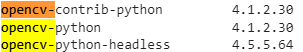

```python
!pip list
```

[output not shown]

[output cut: 362 more lines]

[output not shown]

```python
!pip uninstall opencv-python-headless==4.5.5.62
```

[output not shown]

```python
!pip install opencv-python-headless==4.1.2.30
```

```
     |████████████████████████████████| 21.8 MB 1.7 MB/s
```

```python
import tensorflow as tf
if tf.test.gpu_device_name():
    print('Default GPU Device: {}'.format(tf.test.gpu_device_name()))
else:
    print("Please install GPU version of TF")

tf.config.experimental.set_visible_devices([], 'GPU')
```

```
Please install GPU version of TF
```

### Finally, train!

```python
model_dir = os.path.join(path_dir['MY_MODELS'], MY_MODEL_NAME, 'train/')
print(model_dir)

# Optionally remove content in output model directory to fresh start.
!rm -rf {model_dir}
os.makedirs(model_dir, exist_ok=True)
```

```
/content/gdrive/MyDrive/mida_deep_learning/custom_detector/workspace/proj_facemask/models/my_ssd_mobilenet_v2_320x320_coco17_tpu-8/train/
```

```python
pipeline_fname = files_path['MY_MODEL_PIPELINE_CONFIG']
num_eval_steps = 50
```

```python
!python /content/gdrive/MyDrive/mida_deep_learning/custom_detector/models/research/object_detection/model_main_tf2.py \
    --pipeline_config_path={pipeline_fname} \
    --model_dir={model_dir} \
    --alsologtostderr \
    --num_train_steps={num_steps} \
    --num_eval_steps={num_eval_steps}
```

[output not shown]

[output cut: 137 more lines]

```
 'Loss/regularization_loss': 2293242.5,
 'Loss/total_loss': 2307653.5,
 'learning_rate': 0.4333315}
INFO:tensorflow:Step 1000 per-step time 0.387s
I0417 15:36:01.619638 139960908928896 model_lib_v2.py:707] Step 1000 per-step time 0.387s
INFO:tensorflow:{'Loss/classification_loss': 5.1200523,
 'Loss/localization_loss': 2.4995122,
 'Loss/regularization_loss': 2213484.5,
 'Loss/total_loss': 2213492.0,
 'learning_rate': 0.46666503}
I0417 15:36:01.620049 139960908928896 model_lib_v2.py:708] {'Loss/classification_loss': 5.1200523,
 'Loss/localization_loss': 2.4995122,
 'Loss/regularization_loss': 2213484.5,
 'Loss/total_loss': 2213492.0,
 'learning_rate': 0.46666503}
```

### Observe training on TensorBoard

```python
# The model checkpoints reside in this folder
model_dir
```

```
'/content/gdrive/MyDrive/mida_deep_learning/custom_detector/workspace/proj_facemask/models/my_ssd_mobilenet_v2_320x320_coco17_tpu-8/train/'
```

```python
print(os.listdir(model_dir))
```

```
['train', 'ckpt-1.data-00000-of-00001', 'ckpt-1.index', 'checkpoint', 'ckpt-2.data-00000-of-00001', 'ckpt-2.index']
```

```python
# Load the TensorBoard notebook extension
%load_ext tensorboard
```

```python
%tensorboard --logdir={model_dir}
```

# Step 11: Model evaluation

```python
command_eval = f'python "{files_path["TRAINING_SCRIPT"]}"  --model_dir="{model_dir}" --pipeline_config_path="{files_path["MY_MODEL_PIPELINE_CONFIG"]}" --checkpoint_dir="{model_dir}"'
```

```python
print(command_eval)
```

```
python "/content/gdrive/MyDrive/mida_deep_learning/custom_detector/models/research/object_detection/model_main_tf2.py"  --model_dir="/content/gdrive/MyDrive/mida_deep_learning/custom_detector/workspace/proj_facemask/models/my_ssd_mobilenet_v2_320x320_coco17_tpu-8/train/" --pipeline_config_path="/con…
```

```python
!{command_eval}
```

[output not shown]

[output cut: 101 more lines]

```
I0417 15:52:45.494925 140641145055104 model_lib_v2.py:1018] 	+ DetectionBoxes_Recall/AR@100 (small): 0.000000
INFO:tensorflow:	+ DetectionBoxes_Recall/AR@100 (medium): 0.000000
I0417 15:52:45.495643 140641145055104 model_lib_v2.py:1018] 	+ DetectionBoxes_Recall/AR@100 (medium): 0.000000
INFO:tensorflow:	+ DetectionBoxes_Recall/AR@100 (large): 0.060000
I0417 15:52:45.496407 140641145055104 model_lib_v2.py:1018] 	+ DetectionBoxes_Recall/AR@100 (large): 0.060000
INFO:tensorflow:	+ Loss/localization_loss: 296.354431
I0417 15:52:45.497081 140641145055104 model_lib_v2.py:1018] 	+ Loss/localization_loss: 296.354431
INFO:tensorflow:	+ Loss/classification_loss: 67516.187500
I0417 15:52:45.498328 140641145055104 model_lib_v2.py:1018] 	+ Loss/classification_loss: 67516.187500
INFO:tensorflow:	+ Loss/regularization_loss: 2212695.500000
I0417 15:52:45.499064 140641145055104 model_lib_v2.py:1018] 	+ Loss/regularization_loss: 2212695.500000
INFO:tensorflow:	+ Loss/total_loss: 2280508.000000
I0417 15:52:45.499722 140641145055104 model_lib_v2.py:1018] 	+ Loss/total_loss: 2280508.000000
INFO:tensorflow:Exiting evaluation at step 1000
I0417 15:52:45.662536 140641145055104 model_lib_v2.py:1169] Exiting evaluation at step 1000
```

# Step 12: Export model

```python
OUTPUT_PATH = os.path.join(path_dir['MY_MODELS'], MY_MODEL_NAME, 'export')
command_export = f'python "{files_path["EXPORTER_SCRIPT"]}" --input_type=image_tensor --pipeline_config_path="{files_path["MY_MODEL_PIPELINE_CONFIG"]}" --trained_checkpoint_dir="{model_dir}" --output_directory="{OUTPUT_PATH}"'
```

```python
print(command_export)
```

```
python "/content/gdrive/MyDrive/mida_deep_learning/custom_detector/models/research/object_detection/exporter_main_v2.py" --input_type=image_tensor --pipeline_config_path="/content/gdrive/MyDrive/mida_deep_learning/custom_detector/workspace/proj_facemask/models/my_ssd_mobilenet_v2_320x320_coco17_tpu-…
```

```python
!{command_export}
```

[output not shown]

```python
OUTPUT_PATH
```

```
'/content/gdrive/MyDrive/mida_deep_learning/custom_detector/workspace/proj_facemask/models/my_ssd_mobilenet_v2_320x320_coco17_tpu-8/export'
```

```python
# tar the exported model to be used anywhere
# !tar -czf models.tar.gz {paths['CHECKPOINT_PATH']}

!tar -czf /content/{MY_MODEL_NAME}.tar.gz {OUTPUT_PATH}
print(f"{MY_MODEL_NAME}.tar.gz saved at current directory.")
```

```
tar: Removing leading `/' from member names
my_ssd_mobilenet_v2_320x320_coco17_tpu-8.tar.gz saved at current directory.
```

```python
os.getcwd()
```

```
'/content/gdrive/MyDrive/mida_deep_learning/custom_detector/workspace/proj_facemask'
```

```python
# ONLY in Google Colab
shutil.copy2(f"/content/{MY_MODEL_NAME}.tar.gz", os.getcwd())
```

```
'/content/gdrive/MyDrive/mida_deep_learning/custom_detector/workspace/proj_facemask/my_ssd_mobilenet_v2_320x320_coco17_tpu-8.tar.gz'
```

# Step 13: Load the trained model

```python
print("Our exported model is in:\n", OUTPUT_PATH)
```

```
Our exported model is in:
 /content/gdrive/MyDrive/mida_deep_learning/custom_detector/workspace/proj_facemask/models/my_ssd_mobilenet_v2_320x320_coco17_tpu-8/export
```

```python
#Import the required libraries for Object detection infernece
import time
import tensorflow as tf
from object_detection.utils import label_map_util
from object_detection.utils import visualization_utils as viz_utils
import os
import cv2
import matplotlib.pyplot as plt
%matplotlib inline

# Loading the exported model from the saved_model directory
PATH_TO_SAVED_MODEL = os.path.join(OUTPUT_PATH, "saved_model")

print('Loading model...', end='')
start_time = time.perf_counter()
# LOAD SAVED MODEL AND BUILD DETECTION FUNCTION
detect_fn = tf.saved_model.load(PATH_TO_SAVED_MODEL)
end_time = time.perf_counter()
print(f'Done! Took {end_time - start_time} seconds')
```

```
Loading model...Done! Took 18.27211645299394 seconds
```

```python
# LOAD LABEL MAP DATA
PATH_TO_LABELS = files_path["LABELMAP"]
category_index = label_map_util.create_category_index_from_labelmap(PATH_TO_LABELS,
                                                                    use_display_name=True)
category_index
```

```
{1: {'id': 1, 'name': 'facemask'}}
```

# Step 14: Deploy model

```python
from imutils.paths import list_images
import numpy as np

def load_image_into_numpy_array(path):
    """Load an image from file into a numpy array.
    Puts image into numpy array of shape (height, width, channels), where channels=3 for RGB to feed into tensorflow graph.
    Args:
      path: the file path to the image
    Returns:
      uint8 numpy array with shape (img_height, img_width, 3)
    """
    img = cv2.imread(path)
    # convert from OpenCV's BGR to RGB format
    img = cv2.cvtColor(img, cv2.COLOR_BGR2RGB)
    return np.array(img)

def detect(image_np):
    start_t = time.perf_counter()
    # Running the infernce on the image specified in the  image path
    # The input needs to be a tensor, convert it using `tf.convert_to_tensor`.
    input_tensor = tf.convert_to_tensor(image_np)
    # The model expects a batch of images, so add an axis with `tf.expand_dims`.
    input_tensor = input_tensor[tf.newaxis, ...]
    # input_tensor = tf.expand_dims(input_tensor, 0)

    # running detection using the loaded model
    detections = detect_fn(input_tensor)

    # All outputs are batches tensors.
    # Convert to numpy arrays, and take index [0] to remove the batch dimension.
    # We're only interested in the first num_detections.
    num_detections = int(detections.pop('num_detections'))
    detections = {key: value[0, :num_detections].numpy()
                   for key, value in detections.items()}
    detections['num_detections'] = num_detections

    # detection_classes should be ints.
    detections['detection_classes'] = detections['detection_classes'].astype(np.int64)
    #print(detections['detection_classes'])
    end_t = time.perf_counter()
    print(f'[INFO] Done inference. [{end_t - start_t:.2f} secs]')

    return detections

def draw_results(detections, image_np, min_score_thresh=0.6):
    label_id_offset = 1
    image_np_with_detections = image_np.copy()
    viz_utils.visualize_boxes_and_labels_on_image_array(
                image_np_with_detections,
                detections['detection_boxes'],
                # detections['detection_classes'] + label_id_offset,
                detections['detection_classes'],
                detections['detection_scores'],
                category_index,
                use_normalized_coordinates=True,
                max_boxes_to_draw=20,
                min_score_thresh=min_score_thresh,
                agnostic_mode=False
    )
    return image_np_with_detections
```